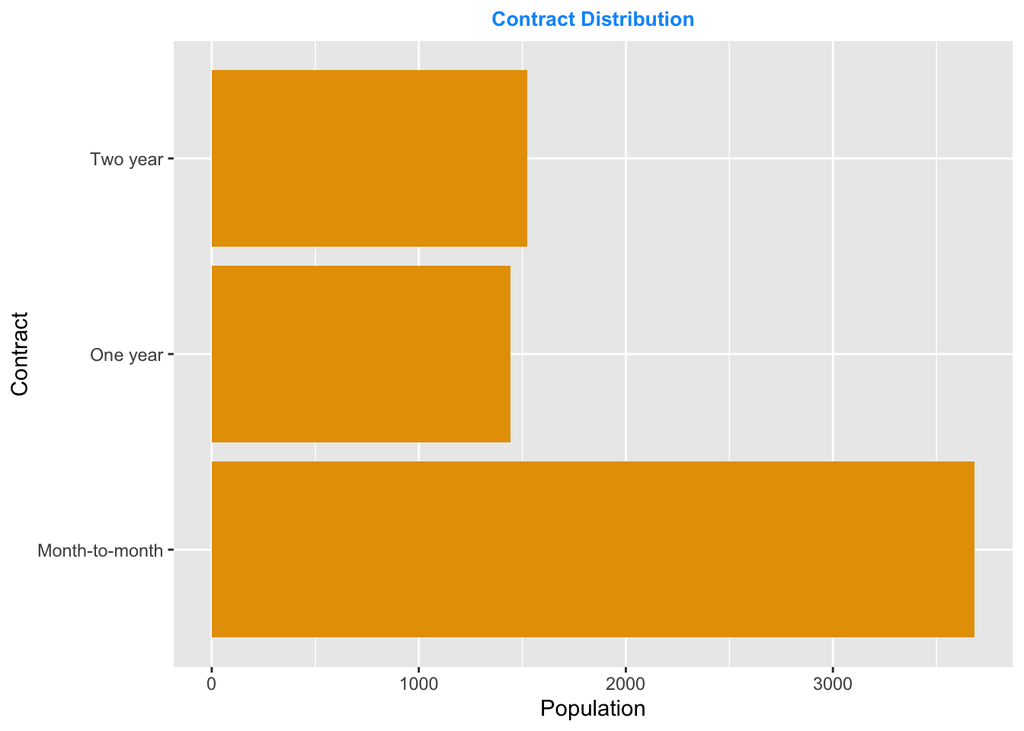

```r
# plotting a pie chart of contract

Contract_Frame<- telecom_2 %>%
  select(contract) %>%
  group_by(contract) %>%
  summarise( Total = n())

ggplot(Contract_Frame,aes(x= Total, y = contract)) +
  geom_col(fill = "#E69F00")+
  labs(
    title = "Contract Distribution",
    x = "Population",
    y = "Contract"
  )+
  theme(
    plot.title = element_text(color = "#0099f9", size = 10, face = "bold", hjust = 0.5),
  )
```

```r
#Majority of the subscribers are on month-to-month contracts, followed by two-year contracts, and then one-year contracts.
```

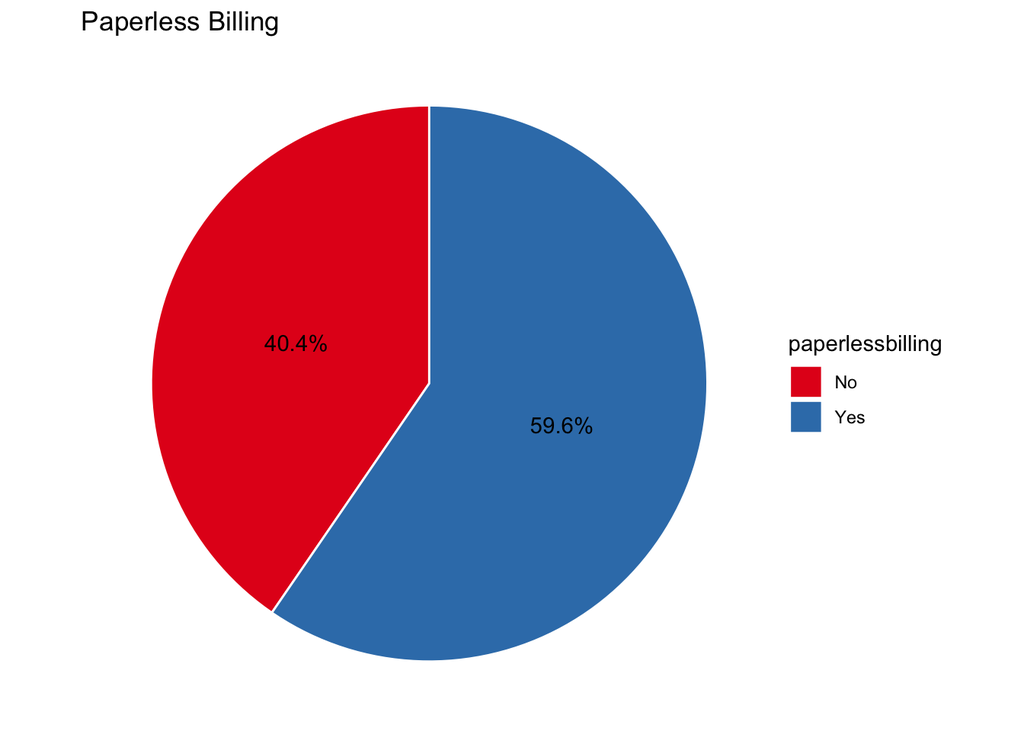

```r
# plotting a pie chart of 'paperless_billing'

Paper_Less<- telecom_2 %>%
  select(paperlessbilling) %>%
  group_by(paperlessbilling) %>%
  summarise( Total = n())



ggplot(Paper_Less, aes(x = "", y = Total, fill = paperlessbilling)) +
  geom_bar(stat = "identity",width =1,color = "white") +
  coord_polar("y",start =0) +
  theme_void()+
  theme(legend.position = "none") +
  geom_text(aes(label = paste0(round(Total/sum(Total) * 100, 1),"%")), position = position_stack(vjust = 0.5)) +
  scale_fill_brewer(palette = "Set1")+
  labs(
    fill = "paperlessbilling",
    title = "Paperless Billing"
  )+
  theme_void()
```

```r
#Observation: A bigger percentage of customers had paperless billing
```

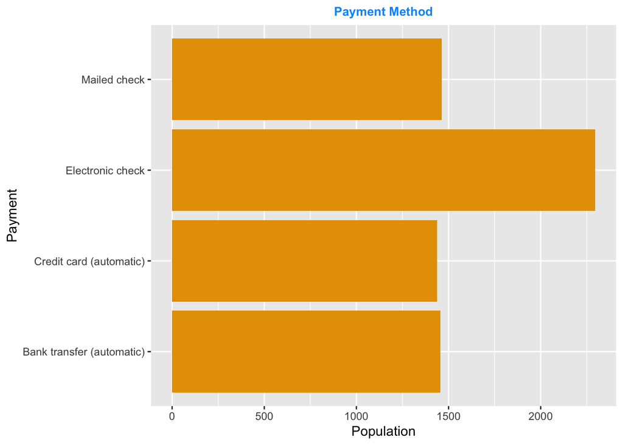

```r
# plotting a horizontal bar chart of payment method
Payment<- telecom_2 %>%
  select(paymentmethod) %>%
  group_by(paymentmethod) %>%
  summarise( Total = n())

ggplot(Payment,aes(x= Total, y = paymentmethod)) +
  geom_col(fill = "#E69F00")+
  labs(
    title = "Payment Method",
    x = "Population",
    y = "Payment"
  )+
  theme(
    plot.title = element_text(color = "#0099f9", size = 10, face = "bold", hjust = 0.5),
  )
```

```r
#Electronic checks are the most popular form of payment while mailed checks, bank transfers, and credit cards are subsequently and similarly common.
```

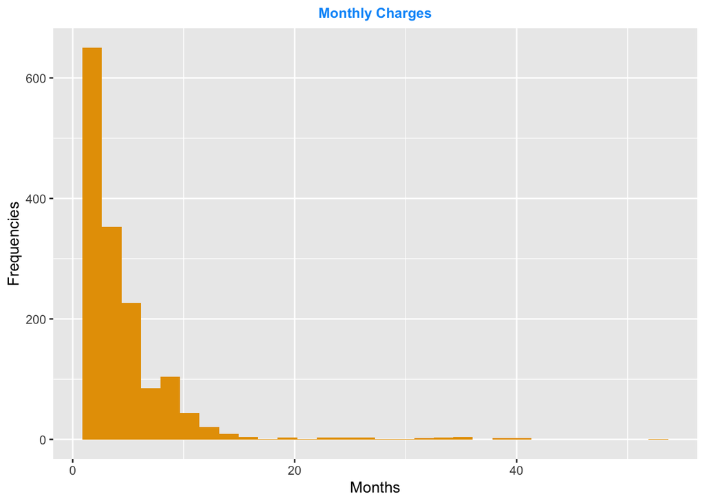

```r
# plotting a distribution of monthly charges

Monthly<- telecom_2 %>%
  select(monthlycharges) %>%
  group_by(monthlycharges) %>%
  summarise( Total = n())

ggplot(Monthly,aes(x= Total)) +
  geom_histogram(fill = "#E69F00")+
  labs(
    title = "Monthly Charges",
    x = "Months",
    y = "Frequencies"
  )+
  theme(
    plot.title = element_text(color = "#0099f9", size = 10, face = "bold", hjust = 0.5),
  )
```

```r
# Between 0 and 5 months are highest
```

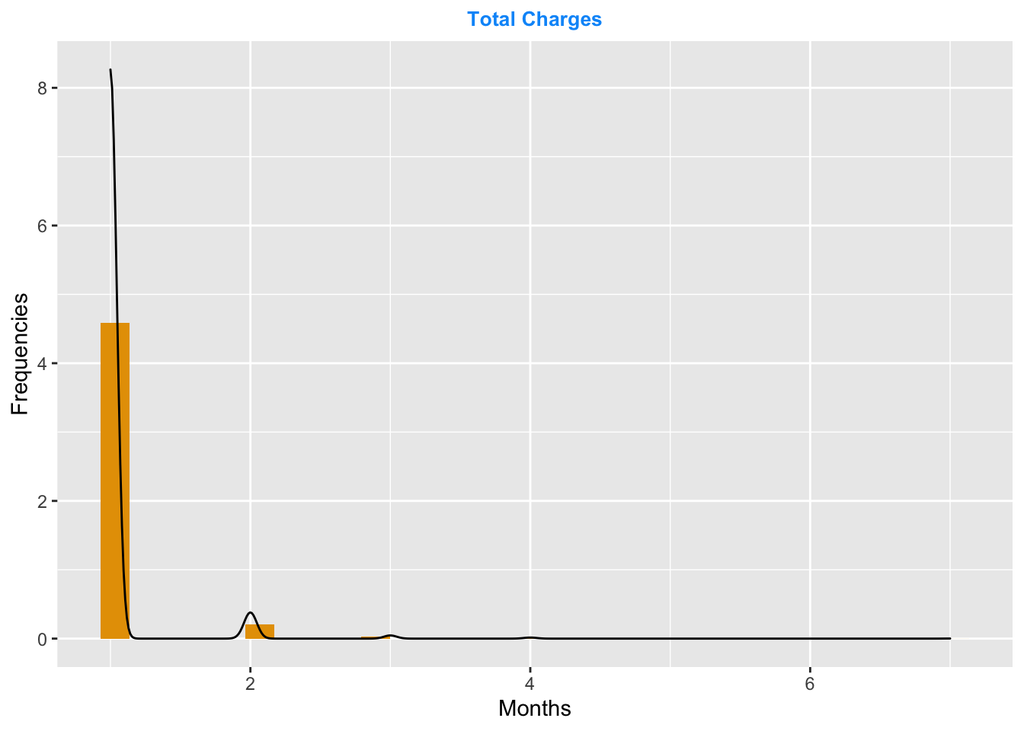

```r
# we plot a distribution plot (kde) of total charges
Total_Charges<- telecom_2 %>%
  select(totalcharges) %>%
  group_by(totalcharges) %>%
  summarise( Total = n())

ggplot(Total_Charges,aes(x= Total)) +
  geom_histogram(fill = "#E69F00",aes(y=..density..))+
  geom_density()+
  labs(
    title = "Total Charges",
    x = "Months",
    y = "Frequencies"
  )+
  theme(
    plot.title = element_text(color = "#0099f9", size = 10, face = "bold", hjust = 0.5),
  )
```

```r
#Majority were in the lower Range
```

Based on the results of the analysis, the following conclusions were arrived at: There is no significant difference in churn rate between male and female subscribers. So this is not an area management needs to worry about. Majority of the customers are not senior citizens so this makes this dataset biased and hard to identify whether being a senior citizen affects churn rate. Not having a partner increases the likelihood of churning. Not having dependents increases the likelihood of churning. Check on Fiber Optics. Are there some outages causing Churn? There is an opportunity to onboard more customers on Mobile segment There is an Opportunity to onobard more customers to back up solution More customers can be onboarded to security Investigate on paperless and why we have some churns

In order to create an effective customer retention program, management should take the following measures: Focus more on meeting the needs of non-senior citizens. Focus more on having customers that have partners and/or dependents since these people are less likely to churn. Alternatively, management can come up with services specifically designed for customers without parters and/or dependents. Come up with more viable products on internet Educate customers on existing products. Check on demographic distribution and how they can use this to retain More Customers Add some wireless solution to cater for segment of customers with fiber optics who are churning Add payment milestones to check on paperless payment

a). Did we have the right data? Do we need other data to answer our question?

As far as I can tell, we had the right data. However, more data is still needed, particularly those with more customers who churned so we can have a better understanding of why they might have churned. b). Did we have the right question?

Yes, we did.